# [Lecture Note] Introduction

MGS3701: Data Mining

Author

Chad (Chungil Chae)

Published

Tue, 27 May 2025

Abstract

This book has by far the most comprehensive review of business analytics methods that the author have ever seen, covering everything from classical approaches such as linear and logistic regression, through to modern methods like neural networks, bagging and boosting, and even much more business specific procedures such as social network analysis and text mining. If not the bible, it is at the least a definitive manual on the subject. However, just as important as the list of topics, is the way that they are all presented in an applied fashion using business applications. Indeed the last chapter is entirely dedicated to 10 separate cases where business analytics approaches can be applied.

# Learning Objectives

1. What Is Business Analytics?
2. What Is Data Mining?
3. Data Mining and Related Terms
4. Big Data
5. Data Science
6. Why Are There So Many Different Methods?
7. Terminology and Notation
8. Road Maps to This Book (Shmueli, Bruce, Yahav, Patel, & Lichtendahl Jr, 2017)

## SHORT VIDEO INTRODUCTION

[video not shown]

# What Is Business Analytics?

- Business analytics (BA) is the use of data analysis methods to support business decision-making.
- Examples of BA applications:
  - Retail (counting sales, basic arithmetic)
  - Advanced customer targeting (e.g., reader behaviors at the Washington Post)
- **Basic Analytics**: Includes simple counting and calculating statistics.
- **Business Intelligence (BI)**: Covers more advanced data analysis practices, including dashboards and interactive reporting.
- Advanced BA includes statistical and machine learning techniques that identify patterns, forecast outcomes, and support decision-making:
  - Regression models for forecasting and scenario planning.
  - A/B testing for marketing campaigns.

## Examples of Business Analytics Applications

- Credit scoring: Predict repayment ability based on historical data.
- Real estate: Predicting home values based on location, market conditions.
- Marketing: Predicting purchase behavior to personalize marketing strategies.
- IRS tax-evasion detection: Enhanced audits using predictive analytics.

# Data Mining Overview

## Overview

- Data mining expands beyond simple data summaries, focusing on advanced analytics for decision-making and prediction.
- Common tasks include prediction, classification, clustering, and association analysis.
- Visualization is an important first step, but the core methods involve statistical and machine-learning algorithms.

## Data Mining in Context

- Foundational techniques originate from statistics and machine learning.
- Different approaches exist based on data availability, computational resources, and desired outcomes.
- Key differences from traditional statistics:
  - Classic statistics focus on inference and general patterns, while data mining emphasizes predictions for individuals.
  - Data mining often skips inference tests common in traditional statistics, making careful training and validation more crucial.

# Big Data

- Big Data refers to datasets characterized by:
  - **Volume**: Very large size.
  - **Velocity**: Generated or updated rapidly.
  - **Variety**: Many different data types (numeric, text, images, video).
  - **Veracity**: Data may be uncertain or inconsistent.
- Big Data enables new analytical possibilities but demands significant computing resources and specialized analytics methods.

## Examples of Big Data Analytics Impact

- IRS identifying tax evasions better through predictive analytics.
- Retailer (Walmart): Use shopper data to optimize inventory.
- Streaming platforms (Spotify, Netflix) using data to offer personalized recommendations and improve user experience.

# Data Science

- Data science involves analytics skills, including statistical techniques, machine learning, and programming expertise.
- Practitioners usually have “T-shaped” skills:
  - Deep expertise in specific technical areas.
  - Broad understanding in other relevant fields (business, IT).
- The role of programming vs. analytics is evolving. Typically:
  - Analysts and data scientists prototype models.
  - IT professionals handle large-scale, automated deployments.

[video not shown]

## Data Science Roles

- **Data Scientist**: Turns data into actionable insights; uses statistics, machine learning, and domain expertise.
- **Data Engineer**: Prepares and organizes datasets; focuses on database management and scalability for analytics projects.

# Why Are There So Many Different Methods?

- No single method is right for all situations. Methods differ because they have distinct strengths, weaknesses, and assumptions.
- Choosing the right method depends on:
  - Dataset size
  - Data types and structure
  - Underlying patterns in data
  - Model assumptions and complexity
- Different algorithms use different approaches (straight lines vs. curves, for example), producing varying results.

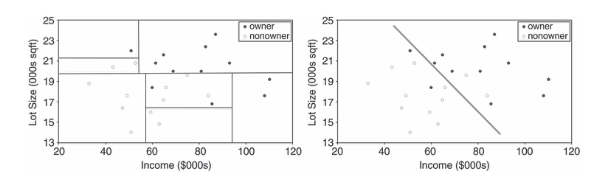

# Terminology and Notation

- Analytics terms originate from statistics and computing, leading to multiple synonymous terms.

## Common Terms

- **Predictor (Attribute, Input Variable)**: a variable used as input to predict outcomes.
- **Observation (case/record)**: An individual unit of analysis in the data.
- **Response (Target/Dependent Variable)**: The variable being predicted or classified.
- **Confidence**: probability of an outcome conditional on another event (used in association rules).
- **Estimation & Prediction**: Modeling numerical outcomes.
- **Supervised Learning**: Using labeled data to train models.
- **Unsupervised Learning**: Identifying patterns without a known outcome variable (e.g., clustering).
- **Validation and Test Sets**: Used for model choice, evaluation, and selecting performance measures.

# Road Maps to This Book

## Structure of Topics

This book has eight main parts: - **Parts I–III (Basics)**: - Concepts, exploration, data preparation. - **Part IV (Supervised Methods)**: - Classification and prediction algorithms. - **Part V (Unsupervised Methods)**: - Association rules, clustering. - **Part VI (Forecasting)**: - Forecasting and modeling time series. - **Part VII (Specialized Techniques)**: - Text mining, social network analytics. - **Part VIII (Advanced/Special Topics)**: - Focused, specialized applications.

- Recommend reading Parts I–III first, to gain foundational knowledge.

# Road Map and Recommended Sequence

- Start with core concepts and basic methods (Chapters 1–4).
- Advanced modeling algorithms (classification & prediction, Chapters 5–13).
- Recommended sequence:
  1. Parts I–III (basics)
  2. Part IV (supervised learning)
  3. Parts V–VIII for specialized topics.

# Preliminary Steps

## Dataset Organization

- Datasets typically have:
  - Variables in columns.
  - Observations or records in rows.
- Example dataset: West Roxbury (Boston home pricing)

## Predictive Example: West Roxbury Home Values

- Zillow-type sites use publicly available property data to estimate prices (“Zestimate”).
- Public data as a starting point is common for home-value prediction models.

## Loading Data in R

- Use CSV file to load data into R as a “data frame”.
- R provides commands for summarizing and exploring variables and data points easily.

## Sampling from Large Databases

- Random subsets sampled from larger datasets for faster processing.
- When classes are unbalanced (fraud or purchase), special oversampling for rare events helps ensure accuracy.

## Data Preprocessing and Cleaning

- Handle different variable types (continuous/categorical/nominal/ordinal).
- Convert categorical data to dummy variables if needed.
- Check for and handle obvious outliers and missing values.
- Normalize (standardize) numeric scales for certain methods.

# Predictive Power and Overfitting

- Predictive power means a model’s ability to generalize well.
- **Overfitting**: Models become too complex, capturing noise instead of real relationships.
- Avoid by partitioning data:
  - **Training** (build)
  - **Validation** (tune model settings)
  - **Testing partition** (final unbiased performance check)

## Cross-Validation for Small Datasets

- Partitioning method helps with small datasets for robust estimates of accuracy.

# Building a Predictive Model Using Regression (Overview):

1. State purpose (price prediction).
2. Obtain data.
3. Explore and clean data (variable checks, dummies creation).
4. Possibly reduce dimensions.
5. Define specific predictive task.
6. Partition data (training vs. validation).
7. Choose & apply the model (regression).
8. Interpret results to pick best model.
9. Deploy model in practical settings (predict new home values).

# Automating and Deploying Models

- Predictive analytics in practice often involves automation, embedding models into business processes.
- Example applications include fraud detection, customer recommendations.
- Deployed models need continuous monitoring and periodic updates as data and situations continually change.

# House management

## Assignment

- What to do
- Requirement
  - PDF format
  - file name should be include your student id and name
    - stuID_name_title.pdf (e.g. 1111111_ChungilChae_SelfIntroduction.pdf)
- Due date
  - by DATE 11:59PM
  - NO LATE SUBMISSION ALLOWED!!!!

## Reference

Shmueli, G., Bruce, P. C., Yahav, I., Patel, N. R., & Lichtendahl Jr, K. C. (2017). *Data mining for business analytics: Concepts, techniques, and applications in r*. John Wiley & Sons.